# STA141A Final Project

Niharika Suravarjjala

June 12th, 2023

# I. Abstract

This report will analyze the feedback type and average spike count of the neural activity of four mice across 18 experimental sessions (with numerous trials in each session). The report will visualize and discuss findings on how the average spike count changes with time, how feedback type varies throughout experiments, and will utilize logistic regression to construct a prediction model for feedback type.

# Background

In this project, we will examine a portion of the information gathered by Steinmetz et al. (2019) during a mouse study. We will concentrate on 18 sessions (Sessions 1 to 18) from four distinct mice: Cori, Frossman, Hence, and Lederberg. The trials were carried out on 10 mice spanning 39 sessions.

The mice were exposed to visual stimuli on two displays that were placed on either side of them throughout each session. The contrast levels of the stimuli varied and could be 0, 0.25, 0.5, or 1. The lack of a stimulus was indicated by a contrast level of 0. The mice had to use a wheel that was controlled by their forepaws to make choices based on visual cues.

The following were the decision criteria:

1. The mouse had to turn the wheel to the right for success or to the left for failure if the contrast on the left screen was higher than the contrast on the right screen.
2. The mouse had to turn the wheel to the left for success or to the right for failure if the contrast on the right screen was higher than the contrast on the left screen.
3. The mouse had to keep the wheel still for success or move it for failure if the left and right contrasts were both zero.
4. To succeed, the mouse had to randomly select either left or right as the proper decision, with a 50% chance of either, if both the left and right contrasts were equal (and non-zero).

Throughout the tests, the brain activity in the mice’s visual cortex was captured. We will pay close attention to the spike trains of neurons between the initiation of the stimuli and 0.4 seconds after the onset. Spike trains are assemblages of time stamps associated with neural activation.

# Objective

The objective of this project is to build a predictive model using the brain activity data (spike trains in spks) and the stimuli (the left and right contrasts). The model will be used to predict the outcome (i.e., feedback type) of each trial.

# Data Structure

1. Feedback Type = type of feedback, Success = 1, Failure = -1
2. Contrast Left = left stimulus contrast
3. Contrast Right = right stimulus contrast
4. Time = centers of the time bins for spks
5. Spks = numbers of spikes of neurons in the visual cortex in time bins defined in time
6. Brain Area = area of the brain where each neuron lives

# III. Exploratory Analysis

In this section, we will explore the features of the data sets to better guide the construction of our prediction model. We will do this by describing data structures across sessions, exploring neurql activities in each trial, exploring changes across trials, and exploring homogeneity and heterogeneity across sessions and mice.

# (i) Data Structures Across Sessions

Features Across Sessions

| Session | Mouse Name | Experiment Date | Brain Areas | Number of Neurons | Number of Trials | Success Rate |
| --- | --- | --- | --- | --- | --- | --- |
| 1 | Cori | 2016-12-14 | 8 | 734 | 114 | 0.61 |
| 2 | Cori | 2016-12-17 | 5 | 1070 | 251 | 0.63 |
| 3 | Cori | 2016-12-18 | 11 | 619 | 228 | 0.66 |
| 4 | Forssmann | 2017-11-01 | 11 | 1769 | 249 | 0.67 |
| 5 | Forssmann | 2017-11-02 | 10 | 1077 | 254 | 0.66 |
| 6 | Forssmann | 2017-11-04 | 5 | 1169 | 290 | 0.74 |
| 7 | Forssmann | 2017-11-05 | 8 | 584 | 252 | 0.67 |
| 8 | Hench | 2017-06-15 | 15 | 1157 | 250 | 0.64 |
| 9 | Hench | 2017-06-16 | 12 | 788 | 372 | 0.69 |
| 10 | Hench | 2017-06-17 | 13 | 1172 | 447 | 0.62 |
| 11 | Hench | 2017-06-18 | 6 | 857 | 342 | 0.80 |
| 12 | Lederberg | 2017-12-05 | 12 | 698 | 340 | 0.74 |
| 13 | Lederberg | 2017-12-06 | 15 | 983 | 300 | 0.80 |
| 14 | Lederberg | 2017-12-07 | 10 | 756 | 268 | 0.69 |
| 15 | Lederberg | 2017-12-08 | 8 | 743 | 404 | 0.76 |
| 16 | Lederberg | 2017-12-09 | 6 | 474 | 280 | 0.72 |
| 17 | Lederberg | 2017-12-10 | 6 | 565 | 224 | 0.83 |
| 18 | Lederberg | 2017-12-11 | 10 | 1090 | 216 | 0.81 |

The above table describes the features across sessions - indicating the mouse, and experiment date of each session, the number of brain areas the experiment covers, the number of neurons activated, the total number of trials, and the success rate of the experiments. Lederberg had the highest number of sessions while Cori had the least. The success rate was lowest for Cori in the 1st session and highest for Lederberg in the 17th session. The metadata provides an overview of the data structures across the 18 sessions before further exploration.

# (ii) Neural Activities During Each Trial

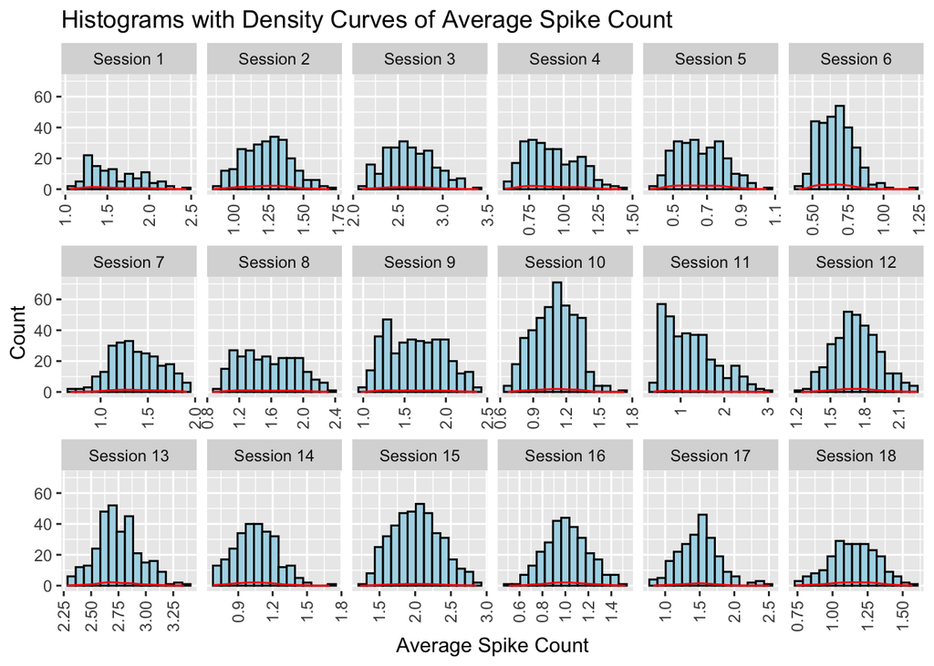

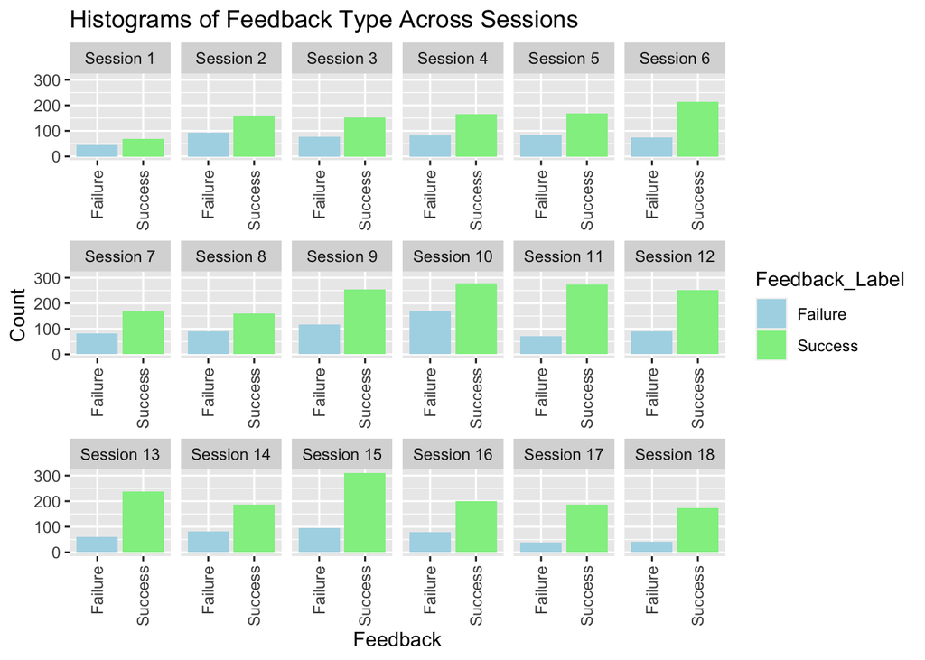

The above figure displays the feedback type across sessions with the x axis representing either a success or failure and the y representing the frequency. Some notable points are that the mice always have more successes than failures even if it gets close on which is greater.

# (iii) Changes Across Trials

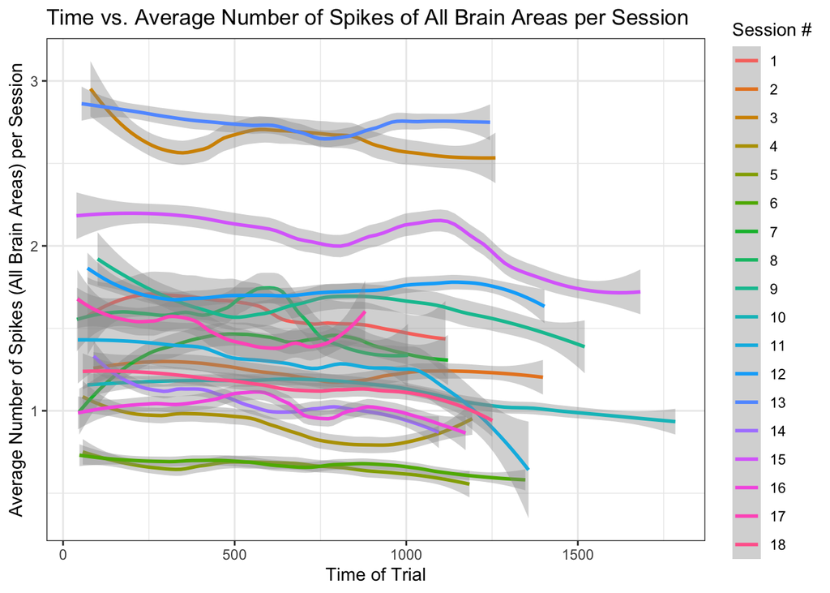

The above plot describes the time of each trial vs the average number of spikes per brain area per session. For the purpose of this figure, the “benchmark” method was employed where the average of all brain spikes in the various brain areas for each session were taken per trial. This information was displayed with some smoothing over the total time of the trials by session.

# (iv) Homogeneity and Heterogeneity across Sessions and Mice

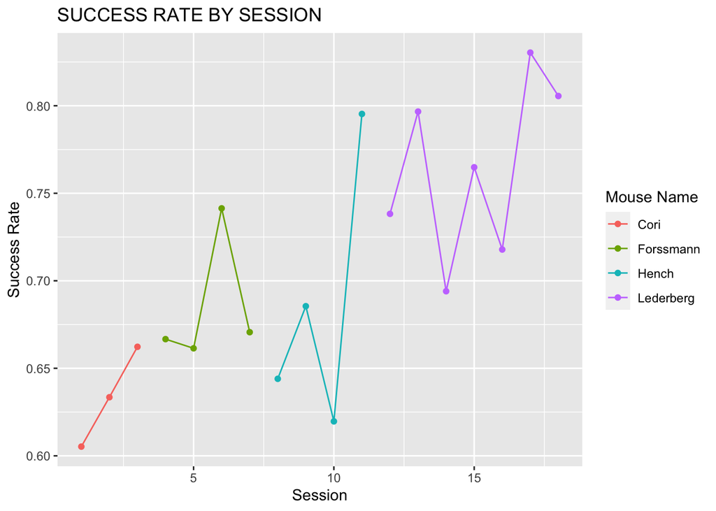

This figure demonstrates the success rate for the different mice across sessions. It is evident that Lederberg has the highest success rates while Cori has the least. It is also interesting to note that the average success rate per mouse begins to increase as we move across session numbers.

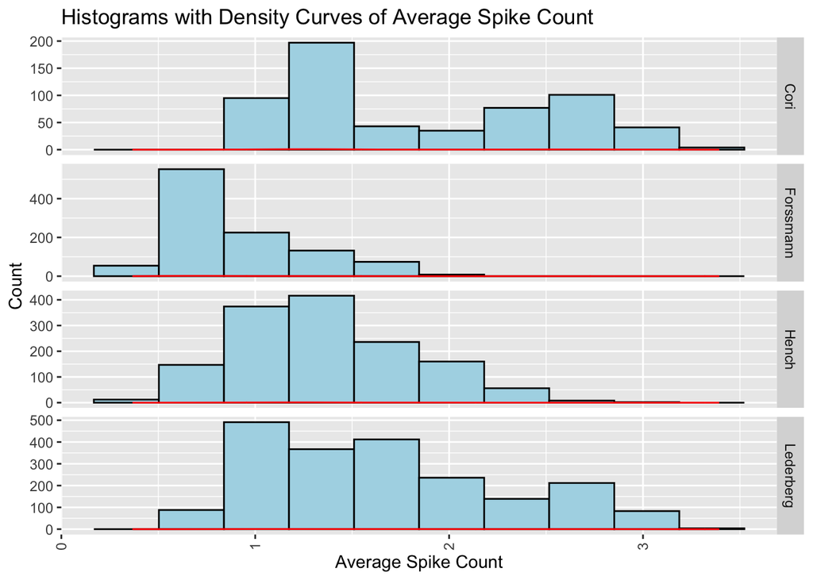

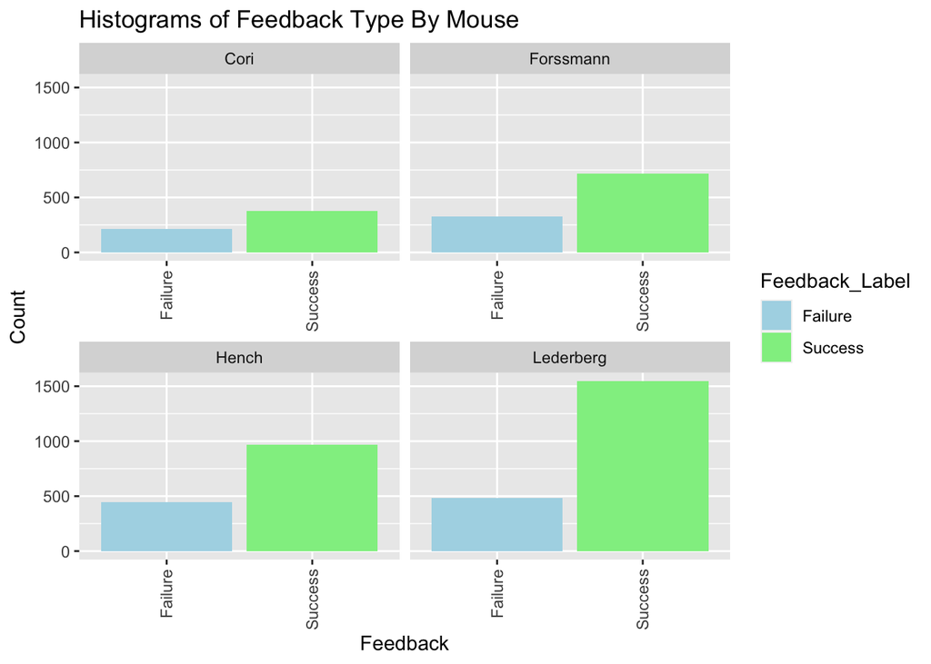

# IV. Data Integration

```
## Importance of components:
##                           PC1    PC2    PC3
## Standard deviation     1.0689 1.0054 0.9202
## Proportion of Variance 0.3808 0.3369 0.2823
## Cumulative Proportion  0.3808 0.7177 1.0000
```

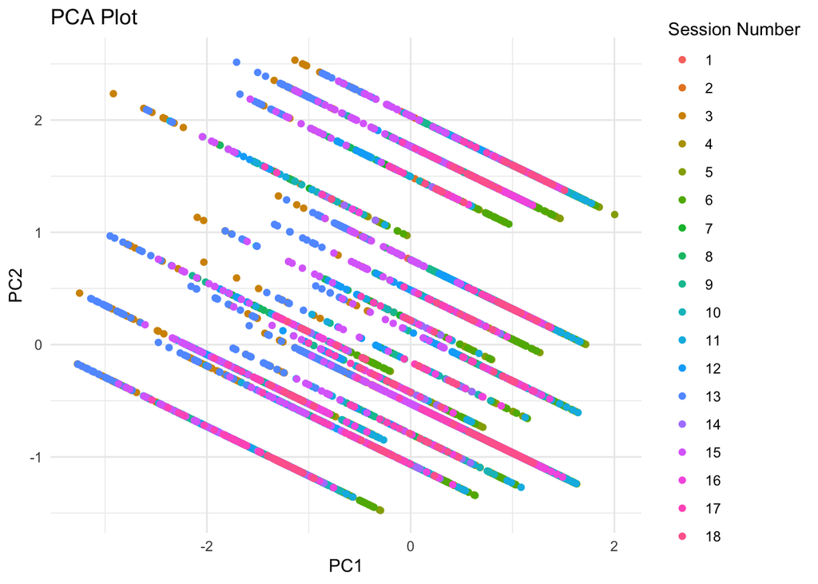

Here we perform principal component analysis on the combined_data dataframe generating a plot reflecting data points on the first two components.Based on the close proximity of the lines from various sessions, we can understand which sessions exude similar characteristics across the features represented in the data frame. The plot highlights that sessions 11,14,and 15 as well as session 1 and 2, and session 2 and 12 are clustered in a very close range indicating matching feature behavior.

# V. Predictive Modeling

The type of feedback, left and right contrast, and spike counts will all be used in this section’s new combined data frame to create a prediction model using logistic regression (method = “glm”), with feedback_type serving as the response variable and the other variables serving as predictors. The confusion matrix and numerous performance measures, including accuracy, sensitivity, specificity, positive predictive value, negative predictive value, prevalence, and others, are also calculated.

```
## Confusion Matrix and Statistics
##
##           Reference
## Prediction  -1   1
##         -1   0   0
##         1   55 145
##
##                Accuracy : 0.725
##                  95% CI : (0.6576, 0.7856)
##     No Information Rate : 0.725
##     P-Value [Acc > NIR] : 0.5362
##
##                   Kappa : 0
##
##  Mcnemar's Test P-Value : 3.305e-13
##
##             Sensitivity : 0.000
##             Specificity : 1.000
##          Pos Pred Value :   NaN
##          Neg Pred Value : 0.725
##              Prevalence : 0.275
##          Detection Rate : 0.000
##    Detection Prevalence : 0.000
##       Balanced Accuracy : 0.500
##
##        'Positive' Class : -1
##
```

# VI. Predictive Performance Results

The output and conclusions from the predictive model that was built in the Predictive Modeling section will be interpreted in this part.The model’s accuracy on the test data is roughly 0.725, which means that in roughly 72.5% of instances, it predicts the feedback_type accurately.The actual positive rate, also known as sensitivity, is 0.0000. This shows that the model has difficulty correctly identifying the positive class or failures (-1).The model does a good job of recognizing the negative class; the specificity, or genuine negative rate, is 1.0000 for successses (1).In the test results, the prevalence of the positive class is roughly 0.275.The agreement between the model’s predictions and the actual feedback_type is gauged by the Kappa statistic. It is 0 in this situation, suggesting that there is no agreement beyond what would be predicted by chance.

# VII. Conclusion and Discussion

These results suggest that the model does not predict the positive class well (-1) and that overall agreement is no better than chance (Kappa = 0). The predicted performance may require additional research and model elaboration. Creating two distinct logistic prediction models on Sessions #1 and #18 to better forecast the positive class and using SVM (Support Vector Machines) instead of logistic are two additional techniques that may be used if more time were available in the future.

## References

1. Distributed coding of choice, action and engagement across the mouse brain - https://www.nature.com/articles/s41586-019-1787-x
2. ChatGPT

### Code Appendix

```r
#Suppress all Warnings
suppressWarnings(library(tidyverse))
suppressWarnings(library(knitr))
suppressWarnings(library(dplyr))
#Empty list to store session data
session=list()

#Read and store the session data for each session (1-18)
for(i in 1:18){
  session[[i]]=readRDS(paste('~/Desktop/everything./stats/sta 141a/Project/sessions/session',i,'.rds',sep=''))
  }

#Calculate the number of sessions
n.session=length(session)

#Create a metadata table using the tidyverse library
meta <- tibble(
  session = 1:n.session,
  mouse_name = rep('name',n.session),
  date_exp =rep('dt',n.session),
  n_brain_area = rep(0,n.session),
  n_neurons = rep(0,n.session),
  n_trials = rep(0,n.session),
  success_rate = rep(0,n.session),
)

# Iterate over each session to extract metadata information
for(i in 1:n.session){
  tmp = session[[i]];
  meta[i,2]=tmp$mouse_name;
  meta[i,3]=tmp$date_exp;
  meta[i,4]=length(unique(tmp$brain_area));
  meta[i,5]=dim(tmp$spks[[1]])[1];
  meta[i,6]=length(tmp$feedback_type);
  meta[i,7]=mean(tmp$feedback_type+1)/2;
}

# Print the metadata table using kable to generate an HTML table
kable(meta, format = "html", table.attr = "class='table table-striped'",digits=2, caption = "Features Across Sessions", align = "c", col.names = c("Session", "Mouse Name", "Experiment Date", "Brain Areas", "Number of Neurons", "Number of Trials", "Success Rate"))

#Session and Trial Indicators
i.s=2
i.t=1

#Retrieve spike train data and brain area for the specified session and trial
spk.trial = session[[i.s]]$spks[[i.t]]
area=session[[i.s]]$brain_area

#Calculate the number of spikes for each neuron during this trial
spk.count=apply(spk.trial,1,sum)

#Calculate the average spike count by brain area using tapply
spk.average.tapply=tapply(spk.count, area, mean)

#Prepare a data frame using dplyr for further analysis
tmp <- data.frame(
  area = area,
  spikes = spk.count
)

#Calculate the average spike count by area using dplyr
spk.average.dplyr =tmp %>%
  group_by(area) %>%
  summarize(mean= mean(spikes))

#Define a function to calculate the average spike area for a given trial
average_spike_area<-function(i.t,this_session){
  spk.trial = this_session$spks[[i.t]]
  area= this_session$brain_area
  spk.count=apply(spk.trial,1,sum)
  spk.average.tapply=tapply(spk.count, area, mean)
  return(spk.average.tapply)
  }

#Test the average_spike_area function with a specific trial and session
#average_spike_area(1,this_session = session[[i.s]])
#Create an empty list to store the trial summary dataframes
trial_summary_list <- vector("list", length = 18)

#Loop over the sessions
for (i.s in 1:18) {
  n.trial <- length(session[[i.s]]$feedback_type)
  n.area <- length(unique(session[[i.s]]$brain_area))

  trial.summary <- matrix(nrow = n.trial, ncol = n.area + 1 + 2 + 1 + 1)

  for (i.t in 1:n.trial) {
    trial.summary[i.t, ] <- c(average_spike_area(i.t, this_session = session[[i.s]]),
                              session[[i.s]]$feedback_type[i.t],
                              session[[i.s]]$contrast_left[i.t],
                              session[[i.s]]$contrast_right[i.t],
                              i.t,
                              session[[i.s]]$time[[i.t]][1])
  }

  colnames(trial.summary) <- c(names(average_spike_area(i.t, this_session = session[[i.s]])),
                               'feedback', 'left_contr', 'right_contr', 'id', 'time')

  trial_summary_df <- as.data.frame(trial.summary)


#Store the trial summary dataframe in the list
  trial_summary_list[[i.s]] <- trial_summary_df
}

# Access each session's trial summary dataframe from the list
# For example, trial summary dataframe for session 1:
session1_trial_summary <- trial_summary_list[[1]]
# For session 2:
session2_trial_summary <- trial_summary_list[[2]]
# Session 3
session3_trial_summary <- trial_summary_list[[3]]
# Session 4
session4_trial_summary <- trial_summary_list[[4]]
# Session 5
session5_trial_summary <- trial_summary_list[[5]]
# Session 6
session6_trial_summary <- trial_summary_list[[6]]
# Session 7
session7_trial_summary <- trial_summary_list[[7]]
# Session 8
session8_trial_summary <- trial_summary_list[[8]]
# Session 9
session9_trial_summary <- trial_summary_list[[9]]
# Session 10
session10_trial_summary <- trial_summary_list[[10]]
# Session 11
session11_trial_summary <- trial_summary_list[[11]]
# Session 12
session12_trial_summary <- trial_summary_list[[12]]
# Session 13
session13_trial_summary <- trial_summary_list[[13]]
# Session 14
session14_trial_summary <- trial_summary_list[[14]]
# Session 15
session15_trial_summary <- trial_summary_list[[15]]
# Session 16
session16_trial_summary <- trial_summary_list[[16]]
# Session 17
session17_trial_summary <- trial_summary_list[[17]]
# Session 18
session18_trial_summary <- trial_summary_list[[18]]



#Append Session 1 Trial Summary Dataframe with Average Spikes Per Brain Area for Each Trial
session1_trial_summary$avgspike = rowMeans(session1_trial_summary[, 1:8])
session1_trial_summary$session_number <- 1
#session1_trial_summary

#Append Session 2 Trial Summary Dataframe with Average Spikes Per Brain Area for Each Trial
session2_trial_summary$avgspike = rowMeans(session2_trial_summary[, 1:5])
session2_trial_summary$session_number <- 2
#session2_trial_summary

#Append Session 3 Trial Summary Dataframe with Average Spikes Per Brain Area for Each Trial
session3_trial_summary$avgspike = rowMeans(session3_trial_summary[, 1:11])
session3_trial_summary$session_number <- 3
#session3_trial_summary

#Append Session 4 Trial Summary Dataframe with Average Spikes Per Brain Area for Each Trial
session4_trial_summary$avgspike = rowMeans(session4_trial_summary[, 1:11])
session4_trial_summary$session_number <- 4
#session4_trial_summary

#Append Session 5 Trial Summary Dataframe with Average Spikes Per Brain Area for Each Trial
session5_trial_summary$avgspike = rowMeans(session5_trial_summary[, 1:10])
session5_trial_summary$session_number <- 5
#session5_trial_summary

#Append Session 6 Trial Summary Dataframe with Average Spikes Per Brain Area for Each Trial
session6_trial_summary$avgspike = rowMeans(session6_trial_summary[, 1:5])
session6_trial_summary$session_number <- 6
#session6_trial_summary
```

```r
#Append Session 7 Trial Summary Dataframe with Average Spikes Per Brain Area for Each Trial
session7_trial_summary$avgspike = rowMeans(session7_trial_summary[, 1:8])
session7_trial_summary$session_number <- 7
#session7_trial_summary

#Append Session 8 Trial Summary Dataframe with Average Spikes Per Brain Area for Each Trial
session8_trial_summary$avgspike = rowMeans(session8_trial_summary[, 1:15])
session8_trial_summary$session_number <- 8
#session8_trial_summary

#Append Session 9 Trial Summary Dataframe with Average Spikes Per Brain Area for Each Trial
session9_trial_summary$avgspike = rowMeans(session9_trial_summary[, 1:12])
session9_trial_summary$session_number <- 9
#session9_trial_summary

#Append Session 10 Trial Summary Dataframe with Average Spikes Per Brain Area for Each Trial
session10_trial_summary$avgspike = rowMeans(session10_trial_summary[, 1:13])
session10_trial_summary$session_number <- 10
#session10_trial_summary

#Append Session 11 Trial Summary Dataframe with Average Spikes Per Brain Area for Each Trial
session11_trial_summary$avgspike = rowMeans(session11_trial_summary[, 1:6])
session11_trial_summary$session_number <- 11
#session11_trial_summary

#Append Session 12 Trial Summary Dataframe with Average Spikes Per Brain Area for Each Trial
session12_trial_summary$avgspike = rowMeans(session12_trial_summary[, 1:12])
session12_trial_summary$session_number <- 12
#session12_trial_summary

#Append Session 13 Trial Summary Dataframe with Average Spikes Per Brain Area for Each Trial
session13_trial_summary$avgspike = rowMeans(session13_trial_summary[, 1:15])
session13_trial_summary$session_number <- 13
#session13_trial_summary

#Append Session 14 Trial Summary Dataframe with Average Spikes Per Brain Area for Each Trial
session14_trial_summary$avgspike = rowMeans(session14_trial_summary[, 1:10])
session14_trial_summary$session_number <- 14
#session14_trial_summary

#Append Session 15 Trial Summary Dataframe with Average Spikes Per Brain Area for Each Trial
session15_trial_summary$avgspike = rowMeans(session15_trial_summary[, 1:8])
session15_trial_summary$session_number <- 15
#session15_trial_summary

#Append Session 16 Trial Summary Dataframe with Average Spikes Per Brain Area for Each Trial
session16_trial_summary$avgspike = rowMeans(session16_trial_summary[, 1:6])
session16_trial_summary$session_number <- 16
#session16_trial_summary

#Append Session 17 Trial Summary Dataframe with Average Spikes Per Brain Area for Each Trial
session17_trial_summary$avgspike = rowMeans(session17_trial_summary[, 1:6])
session17_trial_summary$session_number <- 17
#session17_trial_summary

#Append Session 18 Trial Summary Dataframe with Average Spikes Per Brain Area for Each Trial
session18_trial_summary$avgspike = rowMeans(session18_trial_summary[, 1:10])
session18_trial_summary$session_number <- 18
#session18_trial_summary

# Create a list of your 18 dataframes
dataframes <- list(session1_trial_summary, session2_trial_summary, session3_trial_summary, session4_trial_summary, session5_trial_summary, session6_trial_summary, session7_trial_summary, session8_trial_summary, session9_trial_summary, session10_trial_summary, session11_trial_summary, session12_trial_summary, session13_trial_summary, session14_trial_summary, session15_trial_summary, session16_trial_summary, session17_trial_summary, session18_trial_summary)

# Check column names and structures of the dataframes
common_columns <- intersect(names(dataframes[[1]]), names(dataframes[[2]]))
for (i in 3:length(dataframes)) {
  common_columns <- intersect(common_columns, names(dataframes[[i]]))
}

# Create an empty dataframe with common columns
combined_data <- data.frame()

# Iterate over each dataframe and combine the data
for (i in 1:length(dataframes)) {
  df <- dataframes[[i]]

  # Subset the dataframe to include only common columns
  df <- df[, common_columns]

  # Add a session number column
  df$Session <- paste("Session", i)

  # Append to the combined dataframe
  combined_data <- rbind(combined_data, df)
}

# Print the combined dataframe
#print(combined_data)



# Create an empty data frame
combined_df <- data.frame()

# Iterate over each dataframe and combine avgspike with session number
for (i in 1:length(dataframes)) {
  df <- dataframes[[i]]
  session_num <- paste("Session", i)

  # Create a new data frame with session number and avgspike
  session_df <- data.frame(Session = session_num, AvgSpike = df$avgspike)

  # Append to the combined data frame
  combined_df <- rbind(combined_df, session_df)
}

# Print the combined data frame
#print(combined_df)

library(ggplot2)

# Convert Session to factor with 1-18 session order
combined_df$Session <- factor(combined_df$Session, levels = paste("Session", 1:18))

# Histogram plot for each session
histogram_plot <- ggplot(combined_df, aes(x = AvgSpike)) +
  geom_histogram(aes(y = ..count..), bins = 15, fill = "lightblue", color = "black") +
  geom_density(color = "red") +
  labs(x = "Average Spike Count", y = "Count") +
  ggtitle("Histograms with Density Curves of Average Spike Count") +
  facet_wrap(~ Session, nrow = 3, ncol = 6, scales = "free_x") +
  theme(axis.text.x = element_text(angle = 90, vjust = 0.5, hjust=1))

# Display the plot
print(histogram_plot)


# Create an empty data frame
feedback_df <- data.frame()

# Iterate over each dataframe and combine avgspike with session number
for (i in 1:length(dataframes)) {
  df <- dataframes[[i]]
  session_num <- paste("Session", i)

  # Create a new data frame with session number and feedback
  type_df <- data.frame(Session = session_num, Feedback = df$feedback)

  # Append to the combined data frame
  feedback_df <- rbind(feedback_df, type_df)
}

library(dplyr)

# Create a new column "Feedback_Label" based on "Feedback" column
feedback_df <- feedback_df %>%
  mutate(Feedback_Label = ifelse(Feedback == 1, "Success", "Failure"))


# Print the combined data frame
#print(feedback_df)



# Convert Session to factor with desired order
feedback_df$Session <- factor(feedback_df$Session, levels = paste("Session", 1:18))
```

```r
# Convert Feedback_Label to factor
feedback_df$Feedback_Label <- factor(feedback_df$Feedback_Label, levels = c("Failure", "Success"))

# Set custom fill colors
fill_colors <- c("Failure" = "lightblue", "Success" = "lightgreen")

# Create a histogram plot for each session
histogram_plot <- ggplot(feedback_df, aes(x = Feedback_Label, fill = Feedback_Label)) +
  geom_bar() +
  scale_fill_manual(values = fill_colors) +
  labs(x = "Feedback", y = "Count") +
  ggtitle("Histograms of Feedback Type Across Sessions") +
  facet_wrap(~ Session, nrow = 3, ncol = 6, scales = "free_x") +
  theme(axis.text.x = element_text(angle = 90, vjust = 0.5, hjust = 1))

# Display the plot
print(histogram_plot)


#Create an empty list to store the data for plotting
plot_data <- list()

#Iterate over each dataframe and prepare the data for plotting
for (i in 1:length(dataframes)) {
  df <- dataframes[[i]]
  x <- df$time  # Time of Trial (first value in 4d vector)
  y <- df$avgspike  #Average Number of Spikes in all Brain Areas per Trial

  #Create a new data frame for plotting
  plot_data[[i]] <- data.frame(x = x, y = y, group = as.factor(i))
}

#Combine the data frames from each dataframe into a single data frame
combined_data <- do.call(rbind, plot_data)

# Create the line plot with 18 curves and smoothing
ggplot(combined_data, aes(x = x, y = y, color = group)) +
  geom_smooth(span=0.5) + #span is able to set the level of smoothness
  theme_bw() +
  labs(x = "Time of Trial", y = "Average Number of Spikes (All Brain Areas) per Session", title = "Time vs. Average Number of Spikes of All Brain Areas per Session") +
  labs(color = "Session #")
ggplot(meta, aes(x = session, y = success_rate)) +
  geom_line(aes(color = mouse_name )) +
  geom_point(aes(color = mouse_name )) +
  labs(x = "Session", y= "Success Rate") +
  ggtitle("SUCCESS RATE BY SESSION") +
  scale_color_discrete(name = "Mouse Name")


# Convert Session to factor with desired order
combined_df$Session <- factor(combined_df$Session, levels = paste("Session", 1:18))

# Create a new column for Mouse based on Session numbers
combined_df$Mouse <- factor(
  ifelse(as.integer(gsub("Session", "", combined_df$Session)) %in% 1:3, "Cori",
         ifelse(as.integer(gsub("Session", "", combined_df$Session)) %in% 4:7, "Forssmann",
                ifelse(as.integer(gsub("Session", "", combined_df$Session)) %in% 8:11, "Hench", "Lederberg")))
)

# Create a histogram plot for each mouse
histogram_plot <- ggplot(combined_df, aes(x = AvgSpike)) +
  geom_histogram(aes(y = ..count..), bins = 10, fill = "lightblue", color = "black") +
  geom_density(color = "red") +
  labs(x = "Average Spike Count", y = "Count") +
  ggtitle("Histograms with Density Curves of Average Spike Count") +
  facet_wrap(~ Session, nrow = 3, scales = "free_x") +
  facet_grid(Mouse ~ ., scales = "free_y") +
  theme(axis.text.x = element_text(angle = 90, vjust = 0.5, hjust = 1))

# Display the plot
print(histogram_plot)


# Convert Session to factor with desired order
feedback_df$Session <- factor(feedback_df$Session, levels = paste("Session", 1:18))

# Convert Feedback_Label to factor
feedback_df$Feedback_Label <- factor(feedback_df$Feedback_Label, levels = c("Failure", "Success"))

# Set custom fill colors
fill_colors <- c("Failure" = "lightblue", "Success" = "lightgreen")

# Create a new column for Mouse based on Session numbers
feedback_df$Mouse <- factor(
  ifelse(as.integer(gsub("Session", "", feedback_df$Session)) %in% 1:3, "Cori",
         ifelse(as.integer(gsub("Session", "", feedback_df$Session)) %in% 4:7, "Forssmann",
                ifelse(as.integer(gsub("Session", "", feedback_df$Session)) %in% 8:11, "Hench", "Lederberg")))
)

# Create a histogram plot for each mouse
histogram_plot <- ggplot(feedback_df, aes(x = Feedback_Label, fill = Feedback_Label)) +
  geom_bar() +
  scale_fill_manual(values = fill_colors) +
  labs(x = "Feedback", y = "Count") +
  ggtitle("Histograms of Feedback Type By Mouse") +
  facet_wrap(~ Mouse, nrow = 2, ncol = 2, scales = "free_x") +
  theme(axis.text.x = element_text(angle = 90, vjust = 0.5, hjust = 1))

# Display the plot
print(histogram_plot)

# Create an empty list to store the session-level data
session_data <- list()

# Iterate over each session and prepare the data for modeling
for (i in 1:length(session)) {
  # Extract relevant variables from the session data
  feedback_type <- session[[i]]$feedback_type
  left_contrast <- session[[i]]$contrast_left
  right_contrast <- session[[i]]$contrast_right

  # Add session number to the dataframe
  session_number <- rep(i, length(feedback_type))

  # Combine the variables into a data frame
  session_df <- data.frame(session_number, feedback_type, left_contrast, right_contrast)

  # Append the session dataframe to the list
  session_data[[i]] <- session_df
}

# Combine the session-level data into a single data frame
combined_data <- do.call(rbind, session_data)

# Loop through sessions 2 to 18
for (i in 1:18) {
  # Find the matching rows in combined_data and sessionX_trial_summary based on session_number
  matching_rows <- combined_data$session_number %in% get(paste0("session", i, "_trial_summary"))$session_number

  # Update the avgspike values in combined_data for the matching rows
  combined_data$avgspike[matching_rows] <- get(paste0("session", i, "_trial_summary"))$avgspike
}

# Print the updated combined_data
#combined_data

PCA_data = combined_data[, c("left_contrast", "right_contrast", "avgspike")]
PCA_data = scale(PCA_data)

PCA_result = prcomp(PCA_data, scale. = TRUE)

summary(PCA_result)

PCA_df = as.data.frame(PCA_result$x)

PCA_df$session_number = combined_data$session_number

ggplot(PCA_df, aes(x = PC1, y=PC2, color = as.factor(session_number))) +
  geom_point()+
  labs(color = "Session Number") +
  theme_minimal() +
  ggtitle("PCA Plot")
# Load required libraries
library(caret)

# Create an empty list to store the session-level data
session_data <- list()

# Iterate over each session and prepare the data for modeling
for (i in 1:length(session)) {
  # Extract relevant variables from the session data
  feedback_type <- session[[i]]$feedback_type
  spk_counts <- sapply(session[[i]]$spks, function(x) sum(rowSums(x)))
  left_contrast <- session[[i]]$contrast_left
  right_contrast <- session[[i]]$contrast_right
```

```r
  # Combine the variables into a data frame
  session_data[[i]] <- data.frame(feedback_type, spk_counts, left_contrast, right_contrast)
}

# Combine the session-level data into a single data frame
combined_data <- do.call(rbind, session_data)

combined_data$feedback_type = as.factor(combined_data$feedback_type)

#Empty list to store test data
test=list()

#Read and store the test data for each session (1-2)
for(i in 1:2){
  test[[i]]=readRDS(paste('~/Desktop/everything./stats/sta 141a/Project/test/test',i,'.rds',sep=''))
}


test_data = list()

for(i in 1:length(test)){
  feedback_type <- test[[i]]$feedback_type
  spk_counts <- sapply(test[[i]]$spks, function(x) sum(rowSums(x)))
  left_contrast <- test[[i]]$contrast_left
  right_contrast <- test[[i]]$contrast_right

  # Combine the variables into a data frame
  test_data[[i]] <- data.frame(feedback_type, spk_counts, left_contrast, right_contrast)
}

# Combine the session-level data into a single data frame
test_data <- do.call(rbind, test_data)

test_data$feedback_type = as.factor(test_data$feedback_type)


set.seed(123)
training_data = combined_data
test_data = test_data

model = train(feedback_type ~ ., data = training_data, method = "glm", family = "binomial")

predictions = predict(model, newdata = test_data)

confusion_matrix = confusionMatrix(predictions,test_data$feedback_type)
confusion_matrix
```